# Final_Project4

## Background and Context

AllLife Bank is a US bank that has a growing customer base. The majority of these customers are liability customers (depositors) with varying sizes of deposits. The number of customers who are also borrowers (asset customers) is quite small.

## Objective :

the bank is interested in expanding this base rapidly to bring in more loan business and in the process, earn more through the interest on loans. In particular, the management wants to explore ways of converting its liability customers to personal loan customers (while retaining them as depositors).

1- build LogisticRegression Model To predict whether a liability customer will buy a personal loan or not.

2-Which variables are most significant.

3-Which segment of customers should be targeted more.

### Data Dictionary

- ID: Customer ID
- Age: Customer’s age in completed years
- Experience: #years of professional experience
- Income: Annual income of the customer (in thousand dollars)
- ZIP Code: Home Address ZIP code.
- Family: the Family size of the customer
- CCAvg: Average spending on credit cards per month (in thousand dollars)
- Education: Education Level. 1: Undergrad; 2: Graduate;3: Advanced/Professional
- Mortgage: Value of house mortgage if any. (in thousand dollars)
- Personal_Loan: Did this customer accept the personal loan offered in the last campaign?
- Securities_Account: Does the customer have securities account with the bank?
- CD_Account: Does the customer have a certificate of deposit (CD) account with the bank?
- Online: Do customers use internet banking facilities?
- CreditCard: Does the customer use a credit card issued by any other Bank (excluding All life Bank)?

```python
import pandas as pd
import numpy as np
import scipy.stats as stats
import zipcodes as zcode # to get zipcodes

import matplotlib.pyplot as plt
%matplotlib inline
import seaborn as sns
import warnings

import statsmodels.api as sm
#--Sklearn library--
# Sklearn package's randomized data splitting function
from sklearn.model_selection import train_test_split

from sklearn.metrics import confusion_matrix, classification_report
from sklearn.metrics import accuracy_score,precision_score,recall_score,f1_score
from statsmodels.stats.outliers_influence import variance_inflation_factor
from sklearn import metrics
#AUC ROC curve
from sklearn.metrics import roc_auc_score
from sklearn.metrics import roc_curve
from sklearn.metrics import precision_recall_curve

from sklearn.metrics import confusion_matrix,ConfusionMatrixDisplay #to plot confusion matric
from sklearn.metrics import plot_confusion_matrix

from sklearn.linear_model import LogisticRegression #to build the model
from sklearn.tree import DecisionTreeClassifier#to build the model

pd.set_option('display.float_format', lambda x: '%.3f' % x)
pd.set_option('display.max_rows', 300)
pd.set_option('display.max_colwidth',400)
pd.set_option('display.float_format', lambda x: '%.5f' % x)
# To supress numerical display in scientific notations
warnings.filterwarnings('ignore') # To supress warnings
 # set the background for the graphs
plt.style.use('ggplot')
```

```python
#import csv dataset file
data= pd.read_csv(r'C:\Users\lostsemsem\Desktop\all life bank\Loan_Modelling.csv')
```

```python
# let us make another copy of data
df = data.copy()
```

```python
np.random.seed(1)  # To get the same random results every time
df.sample(n=10)
```

|  | ID | Age | Experience | Income | ZIPCode | Family | CCAvg | Education | Mortgage | Personal_Loan | Securities_Account | CD_Account | Online | CreditCard |
| --- | --- | --- | --- | --- | --- | --- | --- | --- | --- | --- | --- | --- | --- | --- |
| 2764 | 2765 | 31 | 5 | 84 | 91320 | 1 | 2.90000 | 3 | 105 | 0 | 0 | 0 | 0 | 1 |
| 4767 | 4768 | 35 | 9 | 45 | 90639 | 3 | 0.90000 | 1 | 101 | 0 | 1 | 0 | 0 | 0 |
| 3814 | 3815 | 34 | 9 | 35 | 94304 | 3 | 1.30000 | 1 | 0 | 0 | 0 | 0 | 0 | 0 |
| 3499 | 3500 | 49 | 23 | 114 | 94550 | 1 | 0.30000 | 1 | 286 | 0 | 0 | 0 | 1 | 0 |
| 2735 | 2736 | 36 | 12 | 70 | 92131 | 3 | 2.60000 | 2 | 165 | 0 | 0 | 0 | 1 | 0 |
| 3922 | 3923 | 31 | 4 | 20 | 95616 | 4 | 1.50000 | 2 | 0 | 0 | 0 | 0 | 1 | 0 |
| 2701 | 2702 | 50 | 26 | 55 | 94305 | 1 | 1.60000 | 2 | 0 | 0 | 0 | 0 | 1 | 0 |
| 1179 | 1180 | 36 | 11 | 98 | 90291 | 3 | 1.20000 | 3 | 0 | 0 | 1 | 0 | 0 | 1 |
| 932 | 933 | 51 | 27 | 112 | 94720 | 3 | 1.80000 | 2 | 0 | 0 | 1 | 1 | 1 | 1 |
| 792 | 793 | 41 | 16 | 98 | 93117 | 1 | 4.00000 | 3 | 0 | 0 | 0 | 0 | 0 | 1 |

```python
df.info()
```

```
<class 'pandas.core.frame.DataFrame'>
RangeIndex: 5000 entries, 0 to 4999
Data columns (total 14 columns):
 #   Column              Non-Null Count  Dtype
---  ------              --------------  -----
 0   ID                  5000 non-null   int64
 1   Age                 5000 non-null   int64
 2   Experience          5000 non-null   int64
 3   Income              5000 non-null   int64
 4   ZIPCode             5000 non-null   int64
 5   Family              5000 non-null   int64
 6   CCAvg               5000 non-null   float64
 7   Education           5000 non-null   int64
 8   Mortgage            5000 non-null   int64
 9   Personal_Loan       5000 non-null   int64
 10  Securities_Account  5000 non-null   int64
 11  CD_Account          5000 non-null   int64
 12  Online              5000 non-null   int64
 13  CreditCard          5000 non-null   int64
dtypes: float64(1), int64(13)
memory usage: 547.0 KB
```

```python
# check number of rows and columns
df.shape
```

```
(5000, 14)
```

```python
# cheking the number of unique values in each column
df.nunique()
```

```
ID                    5000
Age                     45
Experience              47
Income                 162
ZIPCode                467
Family                   4
CCAvg                  108
Education                3
Mortgage               347
Personal_Loan            2
Securities_Account       2
CD_Account               2
Online                   2
CreditCard               2
dtype: int64
```

```python
#check for duplicated values
df.duplicated().sum()
```

```
0
```

```python
#Check Nulls
df.isnull().sum()
```

```
ID                    0
Age                   0
Experience            0
Income                0
ZIPCode               0
Family                0
CCAvg                 0
Education             0
Mortgage              0
Personal_Loan         0
Securities_Account    0
CD_Account            0
Online                0
CreditCard            0
dtype: int64
```

```python
df.describe()
```

|  | ID | Age | Experience | Income | ZIPCode | Family | CCAvg | Education | Mortgage | Personal_Loan | Securities_Account | CD_Account | Online | CreditCard |
| --- | --- | --- | --- | --- | --- | --- | --- | --- | --- | --- | --- | --- | --- | --- |
| count | 5000.00000 | 5000.00000 | 5000.00000 | 5000.00000 | 5000.00000 | 5000.00000 | 5000.00000 | 5000.00000 | 5000.00000 | 5000.00000 | 5000.00000 | 5000.00000 | 5000.00000 | 5000.00000 |
| mean | 2500.50000 | 45.33840 | 20.10460 | 73.77420 | 93169.25700 | 2.39640 | 1.93794 | 1.88100 | 56.49880 | 0.09600 | 0.10440 | 0.06040 | 0.59680 | 0.29400 |
| std | 1443.52000 | 11.46317 | 11.46795 | 46.03373 | 1759.45509 | 1.14766 | 1.74766 | 0.83987 | 101.71380 | 0.29462 | 0.30581 | 0.23825 | 0.49059 | 0.45564 |
| min | 1.00000 | 23.00000 | -3.00000 | 8.00000 | 90005.00000 | 1.00000 | 0.00000 | 1.00000 | 0.00000 | 0.00000 | 0.00000 | 0.00000 | 0.00000 | 0.00000 |
| 25% | 1250.75000 | 35.00000 | 10.00000 | 39.00000 | 91911.00000 | 1.00000 | 0.70000 | 1.00000 | 0.00000 | 0.00000 | 0.00000 | 0.00000 | 0.00000 | 0.00000 |
| 50% | 2500.50000 | 45.00000 | 20.00000 | 64.00000 | 93437.00000 | 2.00000 | 1.50000 | 2.00000 | 0.00000 | 0.00000 | 0.00000 | 0.00000 | 1.00000 | 0.00000 |
| 75% | 3750.25000 | 55.00000 | 30.00000 | 98.00000 | 94608.00000 | 3.00000 | 2.50000 | 3.00000 | 101.00000 | 0.00000 | 0.00000 | 0.00000 | 1.00000 | 1.00000 |
| max | 5000.00000 | 67.00000 | 43.00000 | 224.00000 | 96651.00000 | 4.00000 | 10.00000 | 3.00000 | 635.00000 | 1.00000 | 1.00000 | 1.00000 | 1.00000 | 1.00000 |

```python
# Checking Experience Negative values
df.sort_values(by=["Age"], ascending=True).head(5)
```

|  | ID | Age | Experience | Income | ZIPCode | Family | CCAvg | Education | Mortgage | Personal_Loan | Securities_Account | CD_Account | Online | CreditCard |
| --- | --- | --- | --- | --- | --- | --- | --- | --- | --- | --- | --- | --- | --- | --- |
| 3157 | 3158 | 23 | -1 | 13 | 94720 | 4 | 1.00000 | 1 | 84 | 0 | 0 | 0 | 1 | 0 |
| 4285 | 4286 | 23 | -3 | 149 | 93555 | 2 | 7.20000 | 1 | 0 | 0 | 0 | 0 | 1 | 0 |
| 2618 | 2619 | 23 | -3 | 55 | 92704 | 3 | 2.40000 | 2 | 145 | 0 | 0 | 0 | 1 | 0 |
| 4411 | 4412 | 23 | -2 | 75 | 90291 | 2 | 1.80000 | 2 | 0 | 0 | 0 | 0 | 1 | 1 |
| 2430 | 2431 | 23 | -1 | 73 | 92120 | 4 | 2.60000 | 1 | 0 | 0 | 0 | 0 | 1 | 0 |

```python
# Checking Experience Negative values
df.sort_values(by=["Age"], ascending=False).head(5)
```

|  | ID | Age | Experience | Income | ZIPCode | Family | CCAvg | Education | Mortgage | Personal_Loan | Securities_Account | CD_Account | Online | CreditCard |
| --- | --- | --- | --- | --- | --- | --- | --- | --- | --- | --- | --- | --- | --- | --- |
| 4468 | 4469 | 67 | 42 | 51 | 94117 | 3 | 2.20000 | 1 | 0 | 0 | 0 | 0 | 1 | 1 |
| 1480 | 1481 | 67 | 42 | 32 | 93943 | 1 | 1.10000 | 3 | 0 | 0 | 0 | 0 | 0 | 1 |
| 4451 | 4452 | 67 | 41 | 18 | 92130 | 2 | 0.40000 | 1 | 0 | 0 | 0 | 0 | 1 | 0 |
| 14 | 15 | 67 | 41 | 112 | 91741 | 1 | 2.00000 | 1 | 0 | 0 | 1 | 0 | 0 | 0 |
| 1859 | 1860 | 67 | 41 | 20 | 91741 | 2 | 0.40000 | 1 | 80 | 0 | 0 | 0 | 0 | 0 |

```python
# Checking the negative values
df[df['Experience'] < 0]['Experience'].value_counts()
```

```
-1    33
-2    15
-3     4
Name: Experience, dtype: int64
```

```python
# Total records of negative experience
df[df['Experience'] < 0]['Experience'].count()
```

```
52
```

#### Observations on the variables:

- There are no Missing or duplicated values .
- The variable ID does not add any interesting information. There is no association between a person's customer ID and loan, also it does not provide any general conclusion for future potential loan customers. We can neglect this information for our model prediction.
- The Experience Variable contains a Negative values which may happened because of Typo error so we will apply abslute value function to revert the negative values back to it's abslute value.
- ZipCode column contains ZipCodes for each customer (467 unique value) which could be converted to counties with python zipcode library to reduce the dimensionality in our dataset and indentifying the regions where the customers have a higher probability to take a personal loan.
- Personal_Loan, Securities_Account, CD_Account, 'Online', 'CreditCard' ,Education are of int/object type, we can change them to category type to reduce the dataspace required.
- The variables can be divided accordingly :

2- Numerical Continous variables are as below:

- Age - Age of the customer.
- Experience - Years of experience.
- Income - Annual income in dollars.
- CCAvg - Average credit card spending.
- Mortage - Value of House Mortgage.

3-Ordinal Categorical Variables are:

- Family - Family size of the customer.
- Education - education level of the customer.

4- The nominal variable is :

- ID
- Zip Code

## Data Preprocessing :

```python
# Processing Experience Column
df.loc[df['Experience']<0,'Experience']=np.abs(df['Experience'])
```

```python
# Checking Experience Negative values
df.sort_values(by=["Age"], ascending=True).head(5)
```

|  | ID | Age | Experience | Income | ZIPCode | Family | CCAvg | Education | Mortgage | Personal_Loan | Securities_Account | CD_Account | Online | CreditCard |
| --- | --- | --- | --- | --- | --- | --- | --- | --- | --- | --- | --- | --- | --- | --- |
| 3157 | 3158 | 23 | 1 | 13 | 94720 | 4 | 1.00000 | 1 | 84 | 0 | 0 | 0 | 1 | 0 |
| 4285 | 4286 | 23 | 3 | 149 | 93555 | 2 | 7.20000 | 1 | 0 | 0 | 0 | 0 | 1 | 0 |
| 2618 | 2619 | 23 | 3 | 55 | 92704 | 3 | 2.40000 | 2 | 145 | 0 | 0 | 0 | 1 | 0 |
| 4411 | 4412 | 23 | 2 | 75 | 90291 | 2 | 1.80000 | 2 | 0 | 0 | 0 | 0 | 1 | 1 |
| 2430 | 2431 | 23 | 1 | 73 | 92120 | 4 | 2.60000 | 1 | 0 | 0 | 0 | 0 | 1 | 0 |

### Processing ZIPCode column

```python
# get unique zipcodes
list_zipcode=df.ZIPCode.unique()
```

```python
# Ceating a dictionary of counties using library zipcode and matching method.
dict_zip={}
for zipcode in list_zipcode:
    my_city_county = zcode.matching(zipcode.astype('str'))
    if len(my_city_county)==1: # if  zipcode is present then get county else, assign zipcode to county
        county=my_city_county[0].get('county')
    else:
        county=zipcode

    dict_zip.update({zipcode:county})
dict_zip
```

```
{91107: 'Los Angeles County',
 90089: 'Los Angeles County',
 94720: 'Alameda County',
 94112: 'San Francisco County',
 91330: 'Los Angeles County',
 92121: 'San Diego County',
 91711: 'Los Angeles County',
 93943: 'Monterey County',
 93023: 'Ventura County',
 94710: 'Alameda County',
 90277: 'Los Angeles County',
 93106: 'Santa Barbara County',
 94920: 'Marin County',
 91741: 'Los Angeles County',
 95054: 'Santa Clara County',
```

[output cut: 452 more lines]

All counties code already satisfiesd expect for 96651,92634,93077,92717.

We can google them to find these missing counties.

```python
dict_zip.update({92717:'Orange County'})
dict_zip.update({92634:'Orange County'})
df['County']=df['ZIPCode'].map(dict_zip)
df.County.nunique()
```

```
40
```

Observation :

- 467 ZIPCodes had been assigned to 40 different counties.

```python
df.info()
```

```
<class 'pandas.core.frame.DataFrame'>
RangeIndex: 5000 entries, 0 to 4999
Data columns (total 15 columns):
 #   Column              Non-Null Count  Dtype
---  ------              --------------  -----
 0   ID                  5000 non-null   int64
 1   Age                 5000 non-null   int64
 2   Experience          5000 non-null   int64
 3   Income              5000 non-null   int64
 4   ZIPCode             5000 non-null   int64
 5   Family              5000 non-null   int64
 6   CCAvg               5000 non-null   float64
 7   Education           5000 non-null   int64
 8   Mortgage            5000 non-null   int64
 9   Personal_Loan       5000 non-null   int64
 10  Securities_Account  5000 non-null   int64
 11  CD_Account          5000 non-null   int64
 12  Online              5000 non-null   int64
 13  CreditCard          5000 non-null   int64
 14  County              5000 non-null   object
dtypes: float64(1), int64(13), object(1)
memory usage: 586.1+ KB
```

```python
# converting object type to category
category_columns = ['Personal_Loan', 'Securities_Account','Family', 'CD_Account', 'Online', 'CreditCard', 'Education','County']
df[category_columns] = df[category_columns].astype('category')
```

```python
# Dropping ID, and ZIPCode Columns
df.drop(['ID','ZIPCode'],axis=1,inplace=True)
```

```python
df.info()
```

```
<class 'pandas.core.frame.DataFrame'>
RangeIndex: 5000 entries, 0 to 4999
Data columns (total 13 columns):
 #   Column              Non-Null Count  Dtype
---  ------              --------------  -----
 0   Age                 5000 non-null   int64
 1   Experience          5000 non-null   int64
 2   Income              5000 non-null   int64
 3   Family              5000 non-null   category
 4   CCAvg               5000 non-null   float64
 5   Education           5000 non-null   category
 6   Mortgage            5000 non-null   int64
 7   Personal_Loan       5000 non-null   category
 8   Securities_Account  5000 non-null   category
 9   CD_Account          5000 non-null   category
 10  Online              5000 non-null   category
 11  CreditCard          5000 non-null   category
 12  County              5000 non-null   category
dtypes: category(8), float64(1), int64(4)
memory usage: 236.8 KB
```

### Expolratory Data Analysis

```python
df.describe().T
```

|  | count | mean | std | min | 25% | 50% | 75% | max |
| --- | --- | --- | --- | --- | --- | --- | --- | --- |
| Age | 5000.00000 | 45.33840 | 11.46317 | 23.00000 | 35.00000 | 45.00000 | 55.00000 | 67.00000 |
| Experience | 5000.00000 | 20.13460 | 11.41519 | 0.00000 | 10.00000 | 20.00000 | 30.00000 | 43.00000 |
| Income | 5000.00000 | 73.77420 | 46.03373 | 8.00000 | 39.00000 | 64.00000 | 98.00000 | 224.00000 |
| CCAvg | 5000.00000 | 1.93794 | 1.74766 | 0.00000 | 0.70000 | 1.50000 | 2.50000 | 10.00000 |
| Mortgage | 5000.00000 | 56.49880 | 101.71380 | 0.00000 | 0.00000 | 0.00000 | 101.00000 | 635.00000 |

observations:

- The Age of customers in our dataset ranges between 23 to 67 with Average 45 years old.
- The Experience ranges from non experienced up to 43 years of experience.
- The Income ranges between 8k per year up to 224k with average Income 73.77k.
- The Average usage on credit cards is 1.93k monthly through our dataset with max of 10k per month.

```python
df.corr()
```

|  | Age | Experience | Income | CCAvg | Mortgage |
| --- | --- | --- | --- | --- | --- |
| Age | 1.00000 | 0.99399 | -0.05527 | -0.05201 | -0.01254 |
| Experience | 0.99399 | 1.00000 | -0.04688 | -0.04974 | -0.01110 |
| Income | -0.05527 | -0.04688 | 1.00000 | 0.64598 | 0.20681 |
| CCAvg | -0.05201 | -0.04974 | 0.64598 | 1.00000 | 0.10990 |
| Mortgage | -0.01254 | -0.01110 | 0.20681 | 0.10990 | 1.00000 |

Observations:

- Age and Experience are extremly correlated on 0.99, Hence we can drop one of them to avoid the multicollinearity between the variables.
- There is Significant high Correlation between Income and CCAvg on 0.645.
- there is low correlation between Mortgage and Income on 0.2.

Let's Calculclate the Coversion rate for Personal Loan(our dependent variable).

```python
df['Personal_Loan'] = df['Personal_Loan'].astype('int')
```

```python
# calculating number of trues and falses in our dependent variable
n_true = len(df.loc[df['Personal_Loan'] == True])
n_false = len(df.loc[df['Personal_Loan'] == False])
print("Number of customers who took Personal Loan: {0} ({1:2.2f}%)".format(n_true, (n_true / (n_true + n_false)) * 100 ))
print("Number of customers who didn't take Personal Loan: {0} ({1:2.2f}%)".format(n_false, (n_false / (n_true + n_false)) * 100))
```

```
Number of customers who took Personal Loan: 480 (9.60%)
Number of customers who didn't take Personal Loan: 4520 (90.40%)
```

```python
 print(df['County'].value_counts())
```

```
Los Angeles County        1095
San Diego County           568
Santa Clara County         563
Alameda County             500
Orange County              366
San Francisco County       257
San Mateo County           204
Sacramento County          184
Santa Barbara County       154
Yolo County                130
Monterey County            128
Ventura County             114
San Bernardino County      101
Contra Costa County         85
Santa Cruz County           68
Riverside County            56
Kern County                 54
Marin County                54
Solano County               33
San Luis Obispo County      33
Humboldt County             32
Sonoma County               28
Fresno County               26
Placer County               24
Butte County                19
Shasta County               18
El Dorado County            17
Stanislaus County           15
San Benito County           14
San Joaquin County          13
Mendocino County             8
Siskiyou County              7
Tuolumne County              7
96651                        6
Lake County                  4
Merced County                4
Trinity County               4
Imperial County              3
Napa County                  3
93077                        1
Name: County, dtype: int64
```

## Univariate Analysis

Let's Check the spread for each variable.

```python
# While doing uni-variate analysis of numerical variables we want to study their central tendency
# and dispersion.
# Let us write a function that will help us create boxplot and histogram for any input numerical
# variable.
# This function takes the numerical column as the input and returns the boxplots
# and histograms for the variable.
# Let us see if this help us write faster and cleaner code.
def histogram_boxplot(feature, figsize=(15,10), bins = None):
    """ Boxplot and histogram combined
    feature: 1-d feature array
    figsize: size of fig (default (9,8))
    bins: number of bins (default None / auto)
    """
    f2, (ax_box2, ax_hist2) = plt.subplots(nrows = 2, # Number of rows of the subplot grid= 2
                                           sharex = True, # x-axis will be shared among all subplots
                                           gridspec_kw = {"height_ratios": (.25, .75)},
                                           figsize = figsize
                                           ) # creating the 2 subplots
    sns.boxplot(feature, ax=ax_box2, showmeans=True, color='violet') # boxplot will be created and a star will indicate the mean value of the column
    sns.distplot(feature, kde=F, ax=ax_hist2, bins=bins,palette="winter") if bins else sns.distplot(feature, kde=False, ax=ax_hist2) # For histogram
    ax_hist2.axvline(np.mean(feature), color='green', linestyle='--') # Add mean to the histogram
    ax_hist2.axvline(np.median(feature), color='black', linestyle='-') # Add median to the histogram
```

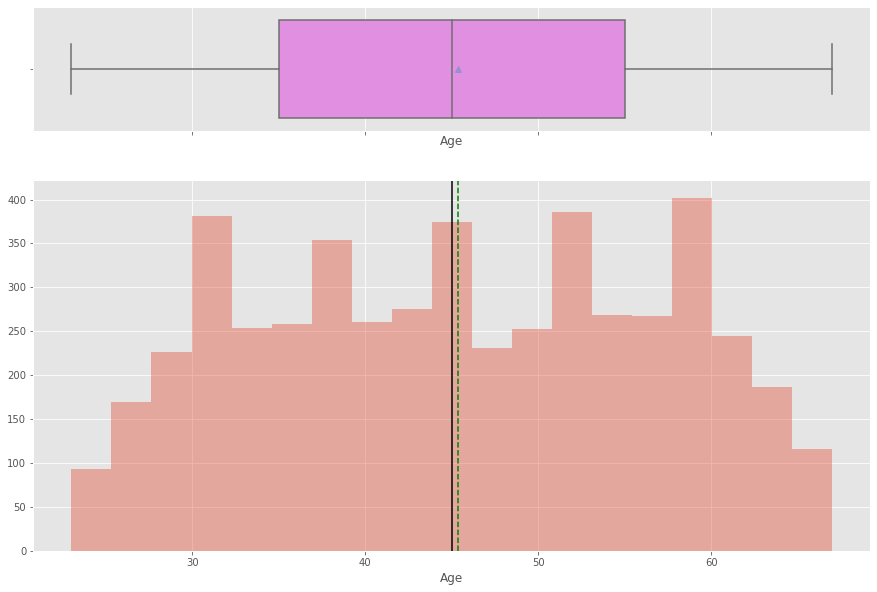

```python
histogram_boxplot(df["Age"])
```

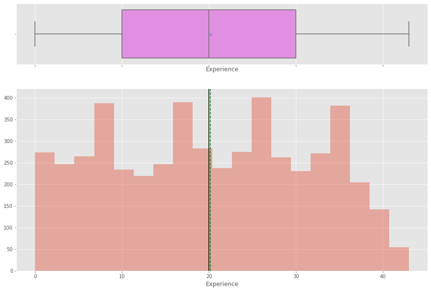

```python
histogram_boxplot(df["Experience"])
```

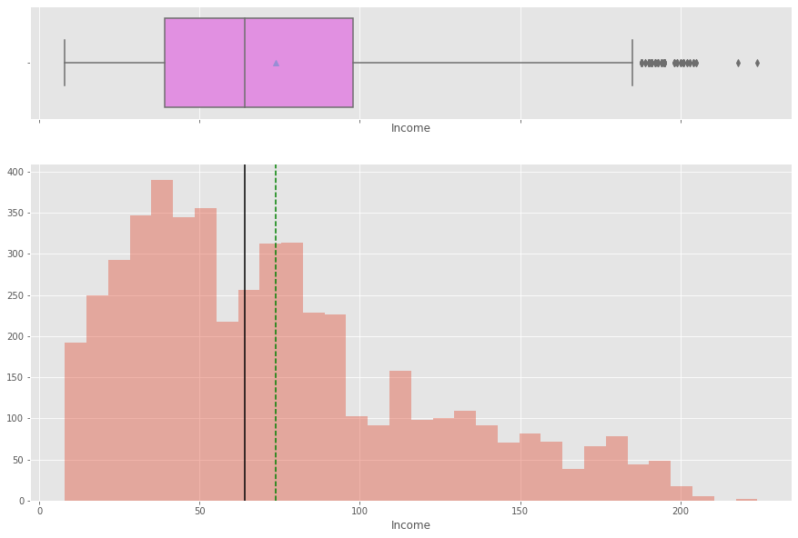

```python
histogram_boxplot(df["Income"])
```

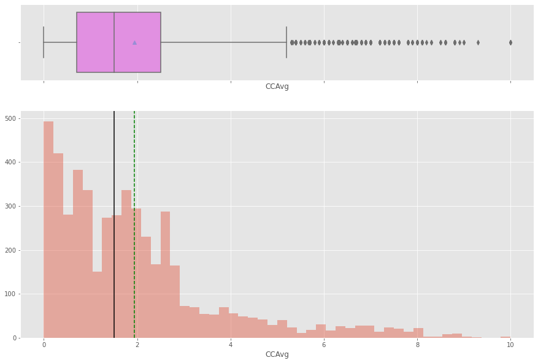

```python
histogram_boxplot(df["CCAvg"])
```

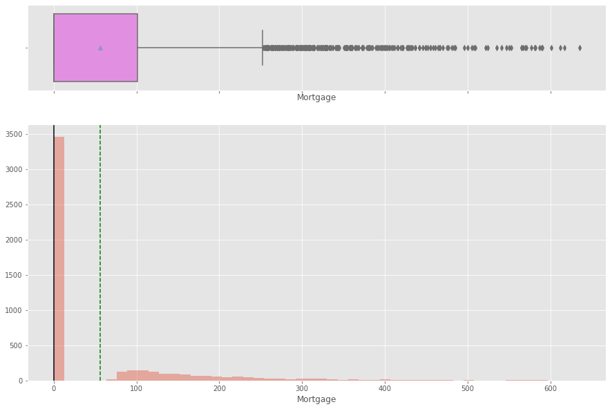

```python
histogram_boxplot(df["Mortgage"])
```

#### Observation:

```python
# Function to create barplots that indicate percentage for each category.

def perc_on_bar(plot, feature):
    '''
    plot
    feature: categorical feature
    the function won't work if a column is passed in hue parameter
    '''
    total = len(feature) # length of the column
    for p in ax.patches:
        percentage = '{:.1f}%'.format(100 * p.get_height()/total) # percentage of each class of the category
        x = p.get_x() + p.get_width() / 2 - 0.05 # width of the plot
        y = p.get_y() + p.get_height()           # hieght of the plot
        ax.annotate(percentage, (x, y), size = 12) # annotate the percantage
    plt.show() # show the plot
```

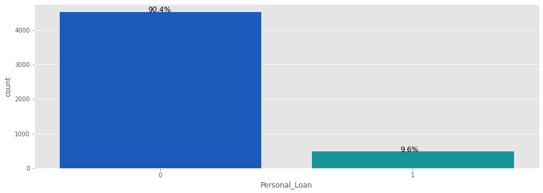

```python
plt.figure(figsize=(15,5))
ax = sns.countplot(data["Personal_Loan"],palette='winter')
perc_on_bar(ax,data["Personal_Loan"])
```

Number of customers who took Personal Loan: 480 (9.60%)

Number of customers who didn't take Personal Loan: 4520 (90.40%

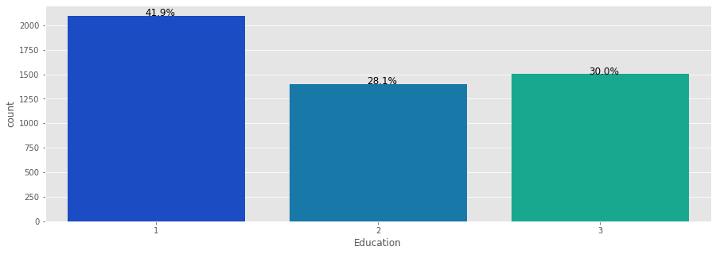

```python
plt.figure(figsize=(15,5))
ax = sns.countplot(data["Education"],palette='winter')
perc_on_bar(ax,data["Education"])
```

Observation:

- 41.9 % of our customers are in an undergraduate stage while 28.1% are graduate and 30% has Advanced/Professional Degree.

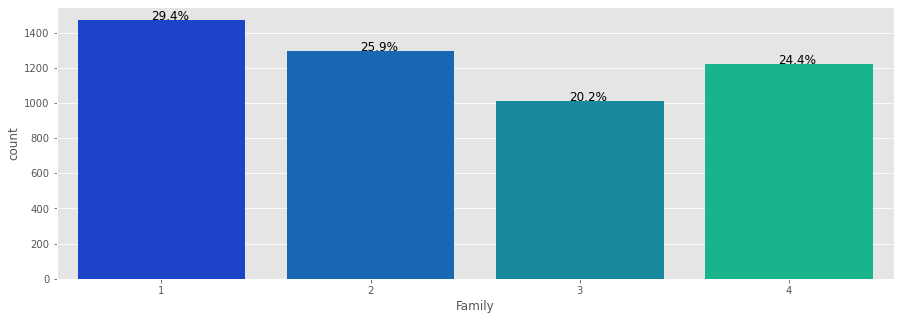

```python
plt.figure(figsize=(15,5))
ax = sns.countplot(data["Family"],palette='winter')
perc_on_bar(ax,data["Family"])
```

Observation:

- Single customers represents the highest count in our dataset while customers who have family size of 2 reprsents 25.9% of our dataset and customers with family size 3 and 4 represents 20.2% and 24.4% of our dataset respectively.

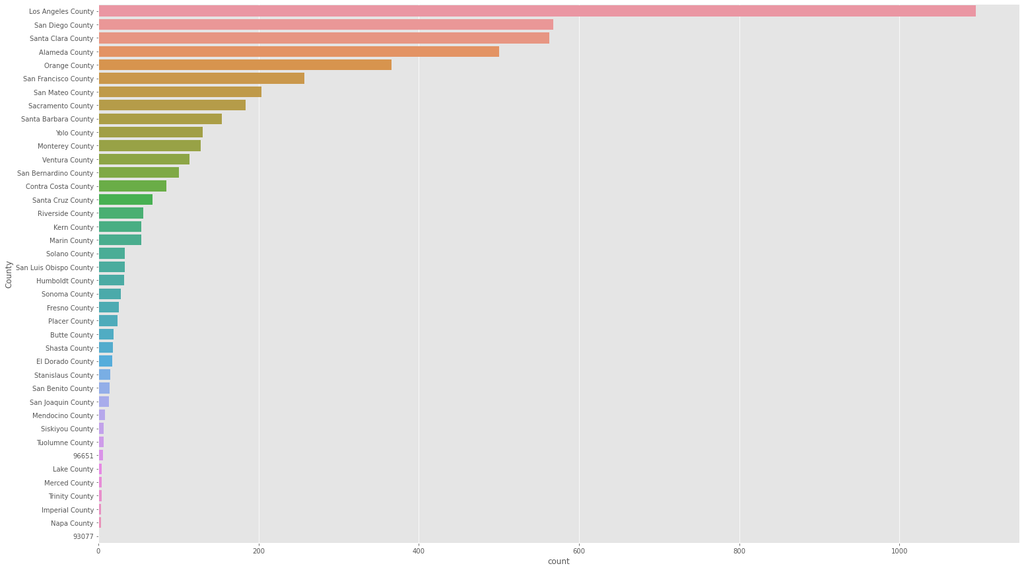

```python
plt.figure(figsize=(25, 15))
sns.countplot(y="County",data=df, order=df["County"].value_counts().index[0:40])
```

Observation:

## Mutltivariate and Bi Variate Analysis

Let's visualize each inpdenent variable with the dependent variable to better understand the relatioship between them.

```python
df.info()
```

```
<class 'pandas.core.frame.DataFrame'>
RangeIndex: 5000 entries, 0 to 4999
Data columns (total 13 columns):
 #   Column              Non-Null Count  Dtype
---  ------              --------------  -----
 0   Age                 5000 non-null   int64
 1   Experience          5000 non-null   int64
 2   Income              5000 non-null   int64
 3   Family              5000 non-null   category
 4   CCAvg               5000 non-null   float64
 5   Education           5000 non-null   category
 6   Mortgage            5000 non-null   int64
 7   Personal_Loan       5000 non-null   int32
 8   Securities_Account  5000 non-null   category
 9   CD_Account          5000 non-null   category
 10  Online              5000 non-null   category
 11  CreditCard          5000 non-null   category
 12  County              5000 non-null   category
dtypes: category(7), float64(1), int32(1), int64(4)
memory usage: 251.4 KB
```

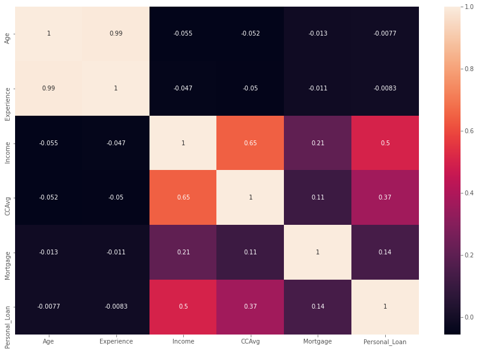

```python
sns.set_palette(sns.color_palette("Set2", 8))
plt.figure(figsize=(15,10))
sns.heatmap(df.corr(),annot=True)
plt.show()
```

#### Observations

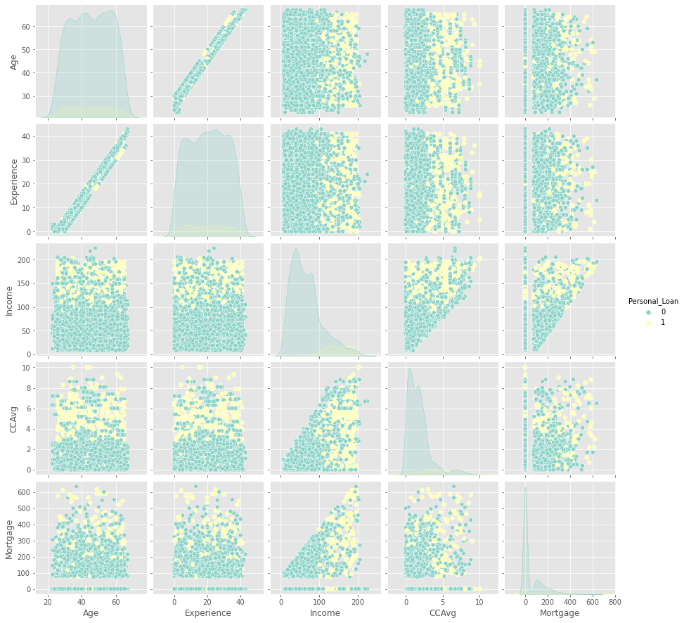

```python
sns.set_palette(sns.color_palette("Set3", 8))
sns.pairplot(df, vars=['Age','Experience','Income','CCAvg','Mortgage'],hue="Personal_Loan")
plt.show()
```

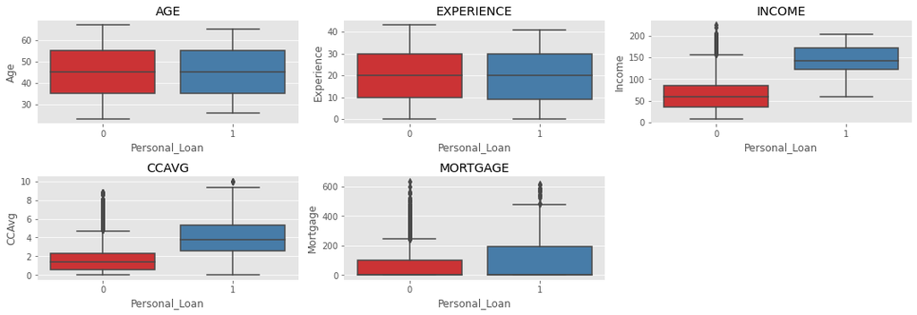

```python
numeric_columns = ['Age','Experience','Income','CCAvg','Mortgage']
plt.figure(figsize=(15,25))

sns.set_palette(sns.color_palette("Set1", 8))
for i, variable in enumerate(numeric_columns):
        plt.subplot(10,3,i+1)

        sns.boxplot(x='Personal_Loan',y= df[variable], data=df)
        sns.despine(top=True,right=True,left=True) # to remove side line from graph
        plt.tight_layout()
        plt.title(variable.upper())
```

```python
## Function to plot stacked bar chart
def stacked_plot(x):
    sns.set_palette(sns.color_palette("Set1", 8))
    tab1 = pd.crosstab(x,df['Personal_Loan'],margins=True)
    print(tab1)
    print('-'*120)
    tab = pd.crosstab(x,df['Personal_Loan'],normalize='index')
    tab.plot(kind='bar',stacked=True,figsize=(7,4))
    plt.xticks(rotation=360)
    labels=["No","Yes"]
    plt.legend(loc='lower left', frameon=False,)
    plt.legend(loc="upper left", labels=labels,title="Borrowed Loan",bbox_to_anchor=(1,1))
    sns.despine(top=True,right=True,left=True) # to remove side line from graph
    #plt.legend(labels)
    plt.show()
```

```
Personal_Loan     0    1   All
Family
1              1365  107  1472
2              1190  106  1296
3               877  133  1010
4              1088  134  1222
All            4520  480  5000
------------------------------------------------------------------------------------------------------------------------
```

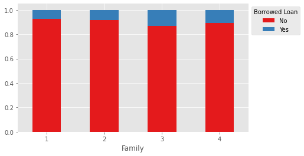

```
Personal_Loan     0    1   All
Education
1              2003   93  2096
2              1221  182  1403
3              1296  205  1501
All            4520  480  5000
------------------------------------------------------------------------------------------------------------------------
```

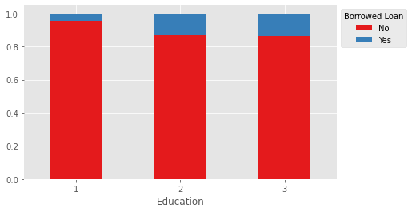

```
Personal_Loan          0    1   All
Securities_Account
0                   4058  420  4478
1                    462   60   522
All                 4520  480  5000
------------------------------------------------------------------------------------------------------------------------
```

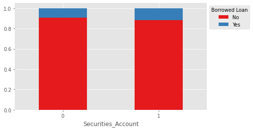

```
Personal_Loan     0    1   All
CD_Account
0              4358  340  4698
1               162  140   302
All            4520  480  5000
------------------------------------------------------------------------------------------------------------------------
```

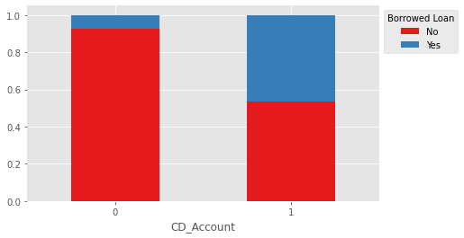

```
Personal_Loan     0    1   All
CreditCard
0              3193  337  3530
1              1327  143  1470
All            4520  480  5000
------------------------------------------------------------------------------------------------------------------------
```

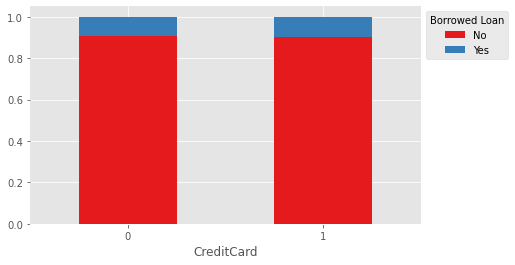

```
Personal_Loan     0    1   All
Online
0              1827  189  2016
1              2693  291  2984
All            4520  480  5000
------------------------------------------------------------------------------------------------------------------------
```

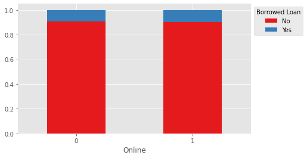

```python
cat_columns=['Family','Education','Securities_Account','CD_Account','CreditCard','Online',]
for i, variable in enumerate(cat_columns):
       stacked_plot(df[variable])
```

Let's reduce the dimensionality by assigning each county into it's Main Region

```python
counties = {
'Los Angeles County':'Los Angeles Region',
'San Diego County':'Southern',
'Santa Clara County':'Bay Area',
'Alameda County':'Bay Area',
'Orange County':'Southern',
'San Francisco County':'Bay Area',
'San Mateo County':'Bay Area',
'Sacramento County':'Central',
'Santa Barbara County':'Southern',
'Yolo County':'Central',
'Monterey County':'Bay Area',
'Ventura County':'Southern',
'San Bernardino County':'Southern',
'Contra Costa County':'Bay Area',
'Santa Cruz County':'Bay Area',
'Riverside County':'Southern',
'Kern County':'Southern',
'Marin County':'Bay Area',
'San Luis Obispo County':'Southern',
'Solano County':'Bay Area',
'Humboldt County':'Superior',
'Sonoma County':'Bay Area',
'Fresno County':'Central',
'Placer County':'Central',
'Butte County':'Superior',
'Shasta County':'Superior',
'El Dorado County':'Central',
'Stanislaus County':'Central',
'San Benito County':'Bay Area',
'San Joaquin County':'Central',
'Mendocino County':'Superior',
'Tuolumne County':'Central',
'Siskiyou County':'Superior',
'Trinity County':'Superior',
'Merced County':'Central',
'Lake County':'Superior',
'Napa County':'Bay Area',
'Imperial County':'Southern',
93077:'Southern',
96651:'Bay Area'
}
```

```python
df['Regions'] = df['County'].map(counties)
```

```python
df['Regions'].unique()
```

```
array(['Los Angeles Region', 'Bay Area', 'Southern', 'Superior',
       'Central'], dtype=object)
```

Observation:

- Now we can drop the County as we assign all the counties in our datset into 5 main regions

```python
df.drop(['County'],axis=1,inplace=True) #droping county
```

```python
df.info()
```

```
<class 'pandas.core.frame.DataFrame'>
RangeIndex: 5000 entries, 0 to 4999
Data columns (total 13 columns):
 #   Column              Non-Null Count  Dtype
---  ------              --------------  -----
 0   Age                 5000 non-null   int64
 1   Experience          5000 non-null   int64
 2   Income              5000 non-null   int64
 3   Family              5000 non-null   category
 4   CCAvg               5000 non-null   float64
 5   Education           5000 non-null   category
 6   Mortgage            5000 non-null   int64
 7   Personal_Loan       5000 non-null   int32
 8   Securities_Account  5000 non-null   category
 9   CD_Account          5000 non-null   category
 10  Online              5000 non-null   category
 11  CreditCard          5000 non-null   category
 12  Regions             5000 non-null   object
dtypes: category(6), float64(1), int32(1), int64(4), object(1)
memory usage: 284.0+ KB
```

```python
df['Regions'] = df['Regions'].astype('category')
```

let's visualize our regions to get more insghts

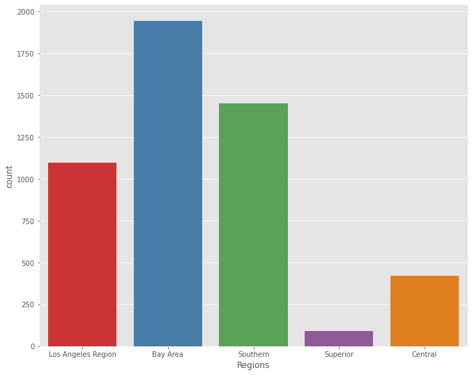

```python
plt.figure(figsize=(11,9))
sns.countplot(data=df,x=df['Regions'])
sns.despine(top=True,right=True,left=True) # to remove side line from graph
```

based o our exploratory data analysis we can conclude that :

- Custoemrs with family size of 3 have a higher conversion rate
- The more educated the customers are the higher conversion rate, as we can see that customers with advanced/Professional degree have a higher probability to take a personal loan.
- Customer with Securities Account represents higher conversion rate to take a personal loan.
- Custoemrs who have a CD account shows significant conversion to take a perosnal through our dataset.
- Customer who have an Online Account shows a little bit higher conversion rate than customers who don't have online account.
- Customer who have a Credit card shows a little bit higher conversion rate than those who don't.
- Most of our customers live in bay area, as well as Southern Regions Regions and Los Angles Region comes in the second and third respectively in terms of count among the five main areas of all the customers in the dataset.
- Customers who have a Higher average usage on thier Credit Cards shows a higher conversion rate comparing to others.
- Customers with Higher Income shows higher probability to take a personal.
- Customers who have Mortgage with us tends to take a personal loan more than others.

### Recommendations on Targeting Personal Loan customers.

- In next Marketing campaign, Exploratorty data analysis recommends to target customers with family size of 3 or more has they have higher probability to take a personal loan.
- we may need to focus on well educated customers as a graudte or professionals if we're seeking in higher conersion rate for Personal loan.
- we need to get closer to customers with CD account and Securities account to understand thier needs and providing them with latest offers on personal loans.
- focusing on customers with High income Profile shows higher conversion rate than other customers, targeting this segment will result in higher conversion rate for the personal loan.
- we can target customers who have a higher average usage and High value of Mortgage as they represents higher probabilty to take a personal loan.
- we need to Focuse on Superior and central areas as they show the least customers through our dataset.

#### Outlier Detection

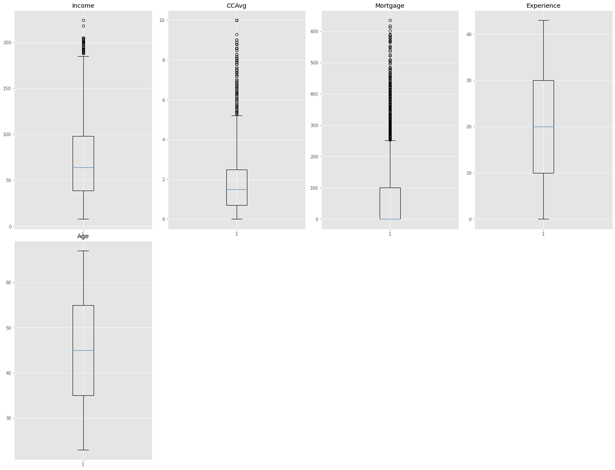

```python
numeric_columns =['Income','CCAvg','Mortgage','Experience','Age']
# outlier detection using boxplot
plt.figure(figsize=(20,30))

for i, variable in enumerate(numeric_columns):
                     plt.subplot(4,4,i+1)
                     plt.boxplot(df[variable],whis=1.5)
                     plt.tight_layout()
                     plt.title(variable)

plt.show()
```

Observation:

There are small number of outliers in the Income Column and some more Outliers in the Higher part of CCAvg and Mortgage variable.

As a banker,

this could be indication of real balanced dataset as the amount of outliers in each variable is not significant enough to affect our model. so we will keep the outliers without treatment to present real-life case.

```python
df.info()
```

```
<class 'pandas.core.frame.DataFrame'>
RangeIndex: 5000 entries, 0 to 4999
Data columns (total 13 columns):
 #   Column              Non-Null Count  Dtype
---  ------              --------------  -----
 0   Age                 5000 non-null   int64
 1   Experience          5000 non-null   int64
 2   Income              5000 non-null   int64
 3   Family              5000 non-null   category
 4   CCAvg               5000 non-null   float64
 5   Education           5000 non-null   category
 6   Mortgage            5000 non-null   int64
 7   Personal_Loan       5000 non-null   int32
 8   Securities_Account  5000 non-null   category
 9   CD_Account          5000 non-null   category
 10  Online              5000 non-null   category
 11  CreditCard          5000 non-null   category
 12  Regions             5000 non-null   category
dtypes: category(7), float64(1), int32(1), int64(4)
memory usage: 250.0 KB
```

No need to revert the Binary variables back into numerical values as it's already represented in our dataset with 0s and 1s.

but we will need to Create dummies for Family, Education and Regions columns.

### Splitting the dataset

```python
# Define Y as dependent variable(personal loan) and X as independent Variables
X =df.drop(['Experience','Personal_Loan'], axis=1)# Drpping Experience column to avoid multicollinearity
Y = df['Personal_Loan']
```

```python
# create dummies for Education, family and Regions columns
Dummies=['Regions','Family','Education']
X=pd.get_dummies(X,columns=Dummies,drop_first=True)
```

```python
#Splitting data in train and test sets
X_train, X_test, y_train, y_test = train_test_split(X,Y, test_size=0.30, random_state = 1,stratify=Y)
```

#### Data Scaling using StandardScaler

Let's reduce the scale of the variables to let the model peform better as there is a big scale between Mortgage(value in 1000 Usd and CCAVG as well, and other variables .

```python
from sklearn.preprocessing import StandardScaler
# Creating StandardScaler instance
scaler = StandardScaler()

# Fitting Standard Scaller
X_scaler = scaler.fit(X_train)

# Scaling data
X_train_scaled = X_scaler.transform(X_train)
X_test_scaled = X_scaler.transform(X_test)

X_train_scaled_df = pd.DataFrame(X_train_scaled,columns=X_train.columns)
X_test_scaled_df = pd.DataFrame(X_test_scaled,columns=X_test.columns)


X_train_scaled_df.index=np.arange(len(X_train_scaled_df))
X_test_scaled_df.index=np.arange(len(X_test_scaled_df))
y_train.index=np.arange(len(y_train))
y_test.index=np.arange(len(y_test))
```

## Building Logistic Regression Model

Objective: Predict whether a liability customer will take personal loan or not.

The main purpose behind our analysis is to identify potential Loan Customers ,so it's important for the bank from busniess prospective is find the customers that are more likely to take a personal loan from the liability customers that are already in the bank.

What Kind of losses that are more significant for the bank to minimize throught our model?

A- Predicting that a customer will take loan while actually he won't.(Loss of Resource)

- False Positive.

B- Predicting that a customer Won't take loan while he will.(Loss of Opportunity)

- False Negative.

In that case it's important from data science prospective to minimize the False negatives.

(the number of customers who will take a loan while the model predict them as not).

So, the right metric to use to check the performance of our logistic model is Recall. the higher the Recall is , the less the number of False negatives.

```python
def make_confusion_matrix(y_actual,y_predict,title):
    fig, ax = plt.subplots(1, 1)

    cm = confusion_matrix(y_actual, y_predict, labels=[0,1])
    disp = ConfusionMatrixDisplay(confusion_matrix=cm,
                               display_labels=["No","Yes"])

    disp.plot(cmap='Reds',ax=ax)
    ax.set_title(title)
    plt.tick_params(axis=u'both', which=u'both',length=0)
    plt.grid(b=None,axis='both',which='both',visible=False)
    plt.show()
```

```python
def get_metrics_score(model,X_train_df,X_test_df,y_train_pass,y_test_pass,statsklearn,threshold=0.5,flag=True,roc=False):
    '''
    Function to calculate different metric scores of the model - Accuracy, Recall, Precision, and F1 score
    model: classifier to predict values of X
    X_train_df, X_test_df: Independent features
    y_train_pass,y_test_pass: Dependent variable
    statsklearn : 0 if calling for Sklearn model else 1
    threshold: thresold for classifiying the observation as 1
    flag: If the flag is set to True then only the print statements showing different will be displayed. The default value is set to True.
    roc: If the roc is set to True then only roc score will be displayed. The default value is set to False.
    '''
    # defining an empty list to store train and test results

    score_list=[]
    if statsklearn==0:
        pred_train = model.predict(X_train_df)
        pred_test = model.predict(X_test_df)
    else:
        pred_train = (model.predict(X_train_df)>threshold)
        pred_test = (model.predict(X_test_df)>threshold)


    pred_train = np.round(pred_train)
    pred_test = np.round(pred_test)

    train_acc = accuracy_score(y_train_pass,pred_train)
    test_acc = accuracy_score(y_test_pass,pred_test)

    train_recall = recall_score(y_train_pass,pred_train)
    test_recall = recall_score(y_test_pass,pred_test)

    train_precision = precision_score(y_train_pass,pred_train)
    test_precision = precision_score(y_test_pass,pred_test)

    train_f1 = f1_score(y_train_pass,pred_train)
    test_f1 = f1_score(y_test_pass,pred_test)


    score_list.extend((train_acc,test_acc,train_recall,test_recall,train_precision,test_precision,train_f1,test_f1))

    if flag == True:
        print("\x1b[0;30;47m \033[1mMODEL PERFORMANCE\x1b[0m")
        print("\x1b[0;30;47m \033[1mAccuracy   : Train:\x1b[0m",
              round(accuracy_score(y_train_pass,pred_train),3),
              "\x1b[0;30;47m \033[1mTest:\x1b[0m ",
              round(accuracy_score(y_test_pass,pred_test),3))
        print("\x1b[0;30;47m \033[1mRecall     : Train:\x1b[0m"
              ,round(recall_score(y_train_pass,pred_train),3),
              "\x1b[0;30;47m \033[1mTest:\x1b[0m" ,
              round(recall_score(y_test_pass,pred_test),3))

        print("\x1b[0;30;47m \033[1mPrecision  : Train:\x1b[0m",
              round(precision_score(y_train_pass,pred_train),3),
              "\x1b[0;30;47m \033[1mTest:\x1b[0m ",
              round(precision_score(y_test_pass,pred_test),3))
        print("\x1b[0;30;47m \033[1mF1         : Train:\x1b[0m",
              round(f1_score(y_train_pass,pred_train),3),
              "\x1b[0;30;47m \033[1mTest:\x1b[0m",
              round(f1_score(y_test_pass,pred_test),3))
        make_confusion_matrix(y_train_pass,pred_train,"Confusion Matrix for Train")
        make_confusion_matrix(y_test_pass,pred_test,"Confusion Matrix for Test")

    if roc == True:

        print("\x1b[0;30;47m \033[1mROC-AUC Score  :Train:\x1b[0m: ",
              round(roc_auc_score(y_train_pass,pred_train),3),
              "\x1b[0;30;47m \033[1mTest:\x1b[0m: ",
              round(roc_auc_score(y_test_pass,pred_test),3))

    return score_list # returning the list with train and test scores
```

### Logistic Regression with Sklearn

```
 MODEL PERFORMANCE
 Accuracy   : Train: 0.655  Test:  0.655
 Recall     : Train: 0.988  Test: 0.972
 Precision  : Train: 0.216  Test:  0.214
 F1         : Train: 0.355  Test: 0.351
```

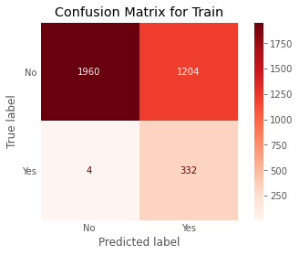

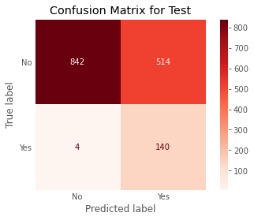

```python
LogisticRegressionModel = LogisticRegression(solver='newton-cg',random_state=1,fit_intercept=False,class_weight={0:0.15,1:0.85})
model  =LogisticRegressionModel.fit(X_train_scaled_df,y_train)

statmodel=0

# Let's check model performances for this model
scores_Sklearn = get_metrics_score(model,X_train_scaled_df,X_test_scaled_df,y_train,y_test,statmodel)
add_score_model(scores_Sklearn)
```

### Logistic Regression with Statsmodel

```
Optimization terminated successfully.
         Current function value: 0.104037
         Iterations 10
 MODEL PERFORMANCE
 Accuracy   : Train: 0.963  Test:  0.953
 Recall     : Train: 0.72  Test: 0.632
 Precision  : Train: 0.877  Test:  0.835
 F1         : Train: 0.791  Test: 0.719
```

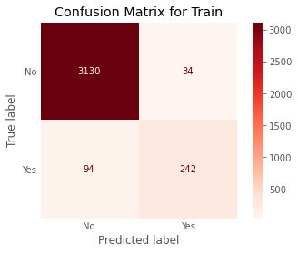

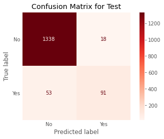

Logit Regression Results

| Dep. Variable: | Personal_Loan | No. Observations: | 3500 |
| --- | --- | --- | --- |
| Model: | Logit | Df Residuals: | 3482 |
| Method: | MLE | Df Model: | 17 |
| Date: | Sat, 17 Jul 2021 | Pseudo R-squ.: | 0.6710 |
| Time: | 23:07:47 | Log-Likelihood: | -364.13 |
| converged: | True | LL-Null: | -1106.7 |
| Covariance Type: | nonrobust | LLR p-value: | 7.710e-306 |

|  | coef | std err | z | P>\|z\| | [0.025 | 0.975] |
| --- | --- | --- | --- | --- | --- | --- |
| const | -5.5428 | 0.253 | -21.916 | 0.000 | -6.038 | -5.047 |
| Age | 0.2050 | 0.101 | 2.033 | 0.042 | 0.007 | 0.403 |
| Income | 3.2256 | 0.190 | 16.997 | 0.000 | 2.854 | 3.598 |
| CCAvg | 0.2647 | 0.103 | 2.568 | 0.010 | 0.063 | 0.467 |
| Mortgage | 0.1221 | 0.077 | 1.582 | 0.114 | -0.029 | 0.273 |
| Securities_Account | -0.2942 | 0.119 | -2.472 | 0.013 | -0.528 | -0.061 |
| CD_Account | 0.8688 | 0.106 | 8.175 | 0.000 | 0.661 | 1.077 |
| Online | -0.3209 | 0.104 | -3.092 | 0.002 | -0.524 | -0.117 |
| CreditCard | -0.4621 | 0.124 | -3.727 | 0.000 | -0.705 | -0.219 |
| Regions_Central | -0.1896 | 0.118 | -1.600 | 0.110 | -0.422 | 0.043 |
| Regions_Los Angeles Region | -0.0610 | 0.107 | -0.569 | 0.570 | -0.271 | 0.149 |
| Regions_Southern | 0.0338 | 0.108 | 0.313 | 0.754 | -0.177 | 0.245 |
| Regions_Superior | -0.2107 | 0.175 | -1.204 | 0.229 | -0.554 | 0.132 |
| Family_2 | -0.1126 | 0.128 | -0.881 | 0.378 | -0.363 | 0.138 |
| Family_3 | 0.7667 | 0.126 | 6.073 | 0.000 | 0.519 | 1.014 |
| Family_4 | 0.6781 | 0.126 | 5.392 | 0.000 | 0.432 | 0.925 |
| Education_2 | 2.0085 | 0.161 | 12.509 | 0.000 | 1.694 | 2.323 |
| Education_3 | 2.0976 | 0.163 | 12.896 | 0.000 | 1.779 | 2.416 |

Possibly complete quasi-separation: A fraction 0.17 of observations can be  
perfectly predicted. This might indicate that there is complete  
quasi-separation. In this case some parameters will not be identified.

```python
# adding constant to training and test set
X_train_stat = sm.add_constant(X_train_scaled_df)
X_test_stat = sm.add_constant(X_test_scaled_df)
statmodel=1  #0 for sklearn and 1 for statmodel
logit = sm.Logit( y_train, X_train_stat.astype(float) )
lg = logit.fit(warn_convergence=False)

# Let's check model performances for this model
scores_statmodel = get_metrics_score(lg,X_train_stat,X_test_stat,y_train,y_test,statmodel)
lg.summary()
```

### Testing the Assumptions:

Multicollinearity we needremove multicollinearity from the dataset to get better coefficients and p-values.

We will useVariation Inflation Factor method to remove multicollinearity.

General Rule of thumb: If VIF is 1 then there is no correlation among the predictor and the remaining predictor variables. Whereas if VIF exceeds 5, we say it shows signs of high multi-collinearity. But the purpose of the analysis should dictate which threshold to use.

```python
# changing datatype of colums to numeric for checking vif
X_train_num = X_train_stat.astype(float).copy()
```

```python
vif_series1 = pd.Series([variance_inflation_factor(X_train_num.values,i) for i in range(X_train_num.shape[1])],index=X_train_num.columns, dtype = float)
print('Series before feature selection: \n\n{}\n'.format(vif_series1))
```

```
Series before feature selection:

const                        1.00000
Age                          1.01539
Income                       1.82477
CCAvg                        1.68656
Mortgage                     1.05058
Securities_Account           1.14067
CD_Account                   1.33312
Online                       1.04741
CreditCard                   1.10707
Regions_Central              1.11898
Regions_Los Angeles Region   1.21718
Regions_Southern             1.23693
Regions_Superior             1.03382
Family_2                     1.39864
Family_3                     1.37655
Family_4                     1.42676
Education_2                  1.25622
Education_3                  1.24101
dtype: float64
```

```python
lg.summary()
```

Logit Regression Results

| Dep. Variable: | Personal_Loan | No. Observations: | 3500 |
| --- | --- | --- | --- |
| Model: | Logit | Df Residuals: | 3482 |
| Method: | MLE | Df Model: | 17 |
| Date: | Sat, 17 Jul 2021 | Pseudo R-squ.: | 0.6710 |
| Time: | 23:11:35 | Log-Likelihood: | -364.13 |
| converged: | True | LL-Null: | -1106.7 |
| Covariance Type: | nonrobust | LLR p-value: | 7.710e-306 |

|  | coef | std err | z | P>\|z\| | [0.025 | 0.975] |
| --- | --- | --- | --- | --- | --- | --- |
| const | -5.5428 | 0.253 | -21.916 | 0.000 | -6.038 | -5.047 |
| Age | 0.2050 | 0.101 | 2.033 | 0.042 | 0.007 | 0.403 |
| Income | 3.2256 | 0.190 | 16.997 | 0.000 | 2.854 | 3.598 |
| CCAvg | 0.2647 | 0.103 | 2.568 | 0.010 | 0.063 | 0.467 |
| Mortgage | 0.1221 | 0.077 | 1.582 | 0.114 | -0.029 | 0.273 |
| Securities_Account | -0.2942 | 0.119 | -2.472 | 0.013 | -0.528 | -0.061 |
| CD_Account | 0.8688 | 0.106 | 8.175 | 0.000 | 0.661 | 1.077 |
| Online | -0.3209 | 0.104 | -3.092 | 0.002 | -0.524 | -0.117 |
| CreditCard | -0.4621 | 0.124 | -3.727 | 0.000 | -0.705 | -0.219 |
| Regions_Central | -0.1896 | 0.118 | -1.600 | 0.110 | -0.422 | 0.043 |
| Regions_Los Angeles Region | -0.0610 | 0.107 | -0.569 | 0.570 | -0.271 | 0.149 |
| Regions_Southern | 0.0338 | 0.108 | 0.313 | 0.754 | -0.177 | 0.245 |
| Regions_Superior | -0.2107 | 0.175 | -1.204 | 0.229 | -0.554 | 0.132 |
| Family_2 | -0.1126 | 0.128 | -0.881 | 0.378 | -0.363 | 0.138 |
| Family_3 | 0.7667 | 0.126 | 6.073 | 0.000 | 0.519 | 1.014 |
| Family_4 | 0.6781 | 0.126 | 5.392 | 0.000 | 0.432 | 0.925 |
| Education_2 | 2.0085 | 0.161 | 12.509 | 0.000 | 1.694 | 2.323 |
| Education_3 | 2.0976 | 0.163 | 12.896 | 0.000 | 1.779 | 2.416 |

Possibly complete quasi-separation: A fraction 0.17 of observations can be  
perfectly predicted. This might indicate that there is complete  
quasi-separation. In this case some parameters will not be identified.

Observation: We can notice that there are some variables have a very high p-values which mean it doesn't add any value to our model , let's drop them all to remove the multicoliinearity except for CCAvg as it's an interested variable as per the EDA .

```python
#Dropping Regions Variables
X_train1 = X_train_stat.drop(['Regions_Central', 'Regions_Los Angeles Region', 'Regions_Southern', 'Regions_Superior'], axis = 1)
X_test1= X_test_stat.drop(['Regions_Central', 'Regions_Los Angeles Region', 'Regions_Southern', 'Regions_Superior'], axis = 1)
logit1 = sm.Logit(y_train, X_train1.astype(float))
lg1 = logit1.fit(warn_convergence =False)

lg1.summary()
```

```
Optimization terminated successfully.
         Current function value: 0.104794
         Iterations 10
```

Logit Regression Results

| Dep. Variable: | Personal_Loan | No. Observations: | 3500 |
| --- | --- | --- | --- |
| Model: | Logit | Df Residuals: | 3486 |
| Method: | MLE | Df Model: | 13 |
| Date: | Sat, 17 Jul 2021 | Pseudo R-squ.: | 0.6686 |
| Time: | 23:15:08 | Log-Likelihood: | -366.78 |
| converged: | True | LL-Null: | -1106.7 |
| Covariance Type: | nonrobust | LLR p-value: | 9.423e-309 |

|  | coef | std err | z | P>\|z\| | [0.025 | 0.975] |
| --- | --- | --- | --- | --- | --- | --- |
| const | -5.5007 | 0.250 | -22.045 | 0.000 | -5.990 | -5.012 |
| Age | 0.2048 | 0.100 | 2.040 | 0.041 | 0.008 | 0.402 |
| Income | 3.2040 | 0.188 | 17.083 | 0.000 | 2.836 | 3.572 |
| CCAvg | 0.2703 | 0.102 | 2.643 | 0.008 | 0.070 | 0.471 |
| Mortgage | 0.1186 | 0.077 | 1.549 | 0.121 | -0.031 | 0.269 |
| Securities_Account | -0.2856 | 0.119 | -2.410 | 0.016 | -0.518 | -0.053 |
| CD_Account | 0.8737 | 0.106 | 8.276 | 0.000 | 0.667 | 1.081 |
| Online | -0.3372 | 0.103 | -3.262 | 0.001 | -0.540 | -0.135 |
| CreditCard | -0.4678 | 0.124 | -3.780 | 0.000 | -0.710 | -0.225 |
| Family_2 | -0.1103 | 0.127 | -0.868 | 0.385 | -0.360 | 0.139 |
| Family_3 | 0.7688 | 0.125 | 6.156 | 0.000 | 0.524 | 1.014 |
| Family_4 | 0.6695 | 0.125 | 5.348 | 0.000 | 0.424 | 0.915 |
| Education_2 | 1.9986 | 0.159 | 12.537 | 0.000 | 1.686 | 2.311 |
| Education_3 | 2.0899 | 0.162 | 12.900 | 0.000 | 1.772 | 2.407 |

Possibly complete quasi-separation: A fraction 0.16 of observations can be  
perfectly predicted. This might indicate that there is complete  
quasi-separation. In this case some parameters will not be identified.

```python
 X_train2 = X_train1.drop(['Age'], axis = 1)
 X_test2= X_test1.drop(['Age'], axis = 1)
 logit2 = sm.Logit(y_train, X_train2.astype(float))
 lg2 = logit2.fit()
 lg2.summary()
```

```
Optimization terminated successfully.
         Current function value: 0.105393
         Iterations 10
```

Logit Regression Results

| Dep. Variable: | Personal_Loan | No. Observations: | 3500 |
| --- | --- | --- | --- |
| Model: | Logit | Df Residuals: | 3487 |
| Method: | MLE | Df Model: | 12 |
| Date: | Sat, 17 Jul 2021 | Pseudo R-squ.: | 0.6667 |
| Time: | 23:22:32 | Log-Likelihood: | -368.87 |
| converged: | True | LL-Null: | -1106.7 |
| Covariance Type: | nonrobust | LLR p-value: | 6.661e-309 |

|  | coef | std err | z | P>\|z\| | [0.025 | 0.975] |
| --- | --- | --- | --- | --- | --- | --- |
| const | -5.4640 | 0.247 | -22.146 | 0.000 | -5.948 | -4.980 |
| Income | 3.1811 | 0.186 | 17.107 | 0.000 | 2.817 | 3.546 |
| CCAvg | 0.2483 | 0.102 | 2.429 | 0.015 | 0.048 | 0.449 |
| Mortgage | 0.1137 | 0.076 | 1.488 | 0.137 | -0.036 | 0.264 |
| Securities_Account | -0.2963 | 0.119 | -2.497 | 0.013 | -0.529 | -0.064 |
| CD_Account | 0.8834 | 0.105 | 8.384 | 0.000 | 0.677 | 1.090 |
| Online | -0.3381 | 0.103 | -3.274 | 0.001 | -0.540 | -0.136 |
| CreditCard | -0.4610 | 0.123 | -3.734 | 0.000 | -0.703 | -0.219 |
| Family_2 | -0.1174 | 0.126 | -0.928 | 0.353 | -0.365 | 0.130 |
| Family_3 | 0.7591 | 0.125 | 6.079 | 0.000 | 0.514 | 1.004 |
| Family_4 | 0.6559 | 0.125 | 5.246 | 0.000 | 0.411 | 0.901 |
| Education_2 | 1.9831 | 0.159 | 12.506 | 0.000 | 1.672 | 2.294 |
| Education_3 | 2.0693 | 0.161 | 12.884 | 0.000 | 1.755 | 2.384 |

Possibly complete quasi-separation: A fraction 0.16 of observations can be  
perfectly predicted. This might indicate that there is complete  
quasi-separation. In this case some parameters will not be identified.

```python
 X_train3 = X_train2.drop(['Mortgage'], axis = 1)
 X_test3= X_test2.drop(['Mortgage'], axis = 1)
 logit3 = sm.Logit(y_train, X_train3.astype(float))
 lg3 = logit3.fit()
 lg3.summary()
```

```
Optimization terminated successfully.
         Current function value: 0.105708
         Iterations 10
```

Logit Regression Results

| Dep. Variable: | Personal_Loan | No. Observations: | 3500 |
| --- | --- | --- | --- |
| Model: | Logit | Df Residuals: | 3488 |
| Method: | MLE | Df Model: | 11 |
| Date: | Sat, 17 Jul 2021 | Pseudo R-squ.: | 0.6657 |
| Time: | 23:24:55 | Log-Likelihood: | -369.98 |
| converged: | True | LL-Null: | -1106.7 |
| Covariance Type: | nonrobust | LLR p-value: | 1.682e-309 |

|  | coef | std err | z | P>\|z\| | [0.025 | 0.975] |
| --- | --- | --- | --- | --- | --- | --- |
| const | -5.4544 | 0.246 | -22.159 | 0.000 | -5.937 | -4.972 |
| Income | 3.2038 | 0.186 | 17.257 | 0.000 | 2.840 | 3.568 |
| CCAvg | 0.2328 | 0.101 | 2.296 | 0.022 | 0.034 | 0.432 |
| Securities_Account | -0.2993 | 0.118 | -2.527 | 0.011 | -0.531 | -0.067 |
| CD_Account | 0.8944 | 0.105 | 8.501 | 0.000 | 0.688 | 1.101 |
| Online | -0.3344 | 0.103 | -3.248 | 0.001 | -0.536 | -0.133 |
| CreditCard | -0.4635 | 0.123 | -3.767 | 0.000 | -0.705 | -0.222 |
| Family_2 | -0.1057 | 0.126 | -0.839 | 0.401 | -0.353 | 0.141 |
| Family_3 | 0.7623 | 0.125 | 6.088 | 0.000 | 0.517 | 1.008 |
| Family_4 | 0.6637 | 0.125 | 5.307 | 0.000 | 0.419 | 0.909 |
| Education_2 | 1.9731 | 0.158 | 12.489 | 0.000 | 1.663 | 2.283 |
| Education_3 | 2.0607 | 0.160 | 12.878 | 0.000 | 1.747 | 2.374 |

Possibly complete quasi-separation: A fraction 0.15 of observations can be  
perfectly predicted. This might indicate that there is complete  
quasi-separation. In this case some parameters will not be identified.

```python
# Let's check model performances for this model and add the scores to our comparisons

scores_statmodel = get_metrics_score(lg3,X_train3,X_test3,y_train,y_test,statmodel)
add_score_model(scores_statmodel)
```

```
 MODEL PERFORMANCE
 Accuracy   : Train: 0.963  Test:  0.958
 Recall     : Train: 0.72  Test: 0.646
 Precision  : Train: 0.874  Test:  0.886
 F1         : Train: 0.79  Test: 0.747
```

### ROC-AUC curve

Roc -Auc curve on Train dataset.

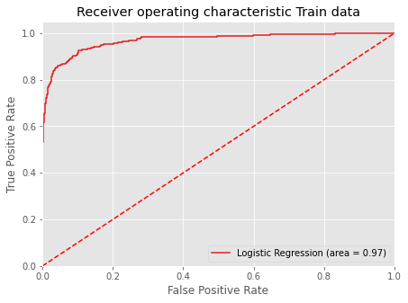

```python
logit_roc_auc_train = roc_auc_score(y_train, lg3.predict(X_train3))
fpr, tpr, thresholds = roc_curve(y_train, lg3.predict(X_train3))
plt.figure(figsize=(7,5))
plt.plot(fpr, tpr, label='Logistic Regression (area = %0.2f)' % logit_roc_auc_train)
plt.plot([0, 1], [0, 1],'r--')
plt.xlim([0.0, 1.0])
plt.ylim([0.0, 1.05])
plt.xlabel('False Positive Rate')
plt.ylabel('True Positive Rate')
plt.title('Receiver operating characteristic Train data')
plt.legend(loc="lower right")
plt.show()
```

Roc-AUC curve on Test dataset

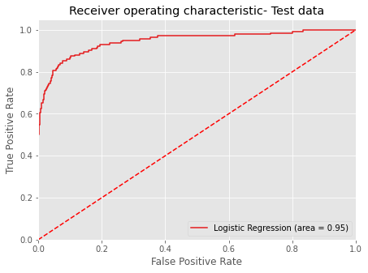

```python
logit_roc_auc_test = roc_auc_score(y_test, lg3.predict(X_test3))
fpr, tpr, thresholds = roc_curve(y_test, lg3.predict(X_test3))
plt.figure(figsize=(7,5))
plt.plot(fpr, tpr, label='Logistic Regression (area = %0.2f)' % logit_roc_auc_test)
plt.plot([0, 1], [0, 1],'r--')
plt.xlim([0.0, 1.0])
plt.ylim([0.0, 1.05])
plt.xlabel('False Positive Rate')
plt.ylabel('True Positive Rate')
plt.title('Receiver operating characteristic- Test data')
plt.legend(loc="lower right")
plt.show()
```

Observation: ROC-AUC value on test dataset is 0.95

#### Coefficient interpretations

Let's calculate the odds ratio

```python
#Calculate Odds Ratio, probability
##create a data frame to collate Odds ratio, probability and p-value of the coef
lgcoef = pd.DataFrame(lg3.params, columns=['coef'])
lgcoef.loc[:, "Odds Ratio"] = np.exp(lgcoef.coef)
lgcoef['Probability'] = lgcoef['Odds Ratio']/(1+lgcoef['Odds Ratio'])
lgcoef['Percentage Change of Odds']=(np.exp(lg3.params)-1)*100
lgcoef['pval']=lg3.pvalues
pd.options.display.float_format = '{:.2f}'.format
lgcoef = lgcoef.sort_values(by="Odds Ratio", ascending=False)
lgcoef
```

|  | coef | Odds Ratio | Probability | Percentage Change of Odds | pval |
| --- | --- | --- | --- | --- | --- |
| Income | 3.20 | 24.63 | 0.96 | 2362.55 | 0.00 |
| Education_3 | 2.06 | 7.85 | 0.89 | 685.17 | 0.00 |
| Education_2 | 1.97 | 7.19 | 0.88 | 619.28 | 0.00 |
| CD_Account | 0.89 | 2.45 | 0.71 | 144.59 | 0.00 |
| Family_3 | 0.76 | 2.14 | 0.68 | 114.33 | 0.00 |
| Family_4 | 0.66 | 1.94 | 0.66 | 94.19 | 0.00 |
| CCAvg | 0.23 | 1.26 | 0.56 | 26.21 | 0.02 |
| Family_2 | -0.11 | 0.90 | 0.47 | -10.03 | 0.40 |
| Securities_Account | -0.30 | 0.74 | 0.43 | -25.87 | 0.01 |
| Online | -0.33 | 0.72 | 0.42 | -28.42 | 0.00 |
| CreditCard | -0.46 | 0.63 | 0.39 | -37.10 | 0.00 |
| const | -5.45 | 0.00 | 0.00 | -99.57 | 0.00 |

### Objective 2 :Which variables are most significant.?

we can see that the Most Significant independent variables that affect Personal loan ( dependent variable) are:

Income, Family, Educatin, CD_Account and CCAvg.

```python
# Let's check model performances for this model
scores_LR = get_metrics_score(lg3,X_train3,X_test3,y_train,y_test,statmodel)
```

```
 MODEL PERFORMANCE
 Accuracy   : Train: 0.963  Test:  0.958
 Recall     : Train: 0.72  Test: 0.646
 Precision  : Train: 0.874  Test:  0.886
 F1         : Train: 0.79  Test: 0.747
```

### Insights:

True Positives:

Reality: A customer wanted to take personal Loan. Model Prediction: The customer will take personal loan. Outcome: The model is good.

True Negatives:

Reality: A customer didn't wanted to take personal loan. Model Prediction: The customer will not take personal loan. Outcome: The business is unaffected .

False Positives :

Reality: A customer didn't want to take personal loan. Model Prediction: The customer will take personal loan. Outcome: The team which is targeting the potential customers would waste their resources on the customers who will not be buying a personal loan.

False Negatives:

Reality: A customer wanted to take personal Loan. Model Prediction: The customer will not take personal loan. Outcome: The potential customer is missed by the salesteam. This is loss of oppurtunity. The purpose of campaign was to target such customers. If team knew about this customers, they could have offered some good APR /interest rates.

#### Optimal Threshold Using AUC-ROC curve

```python
# Optimal threshold as per AUC-ROC curve
# The optimal cut off would be where tpr is high and fpr is low
#fpr, tpr, thresholds = metrics.roc_curve(y_test, lg2.predict(X_test2))

optimal_idx = np.argmax(tpr - fpr)
optimal_threshold_auc_roc = thresholds[optimal_idx]
print(optimal_threshold_auc_roc)
```

```
0.12366057291718258
```

```
 MODEL PERFORMANCE
 Accuracy   : Train: 0.925  Test:  0.917
 Recall     : Train: 0.875  Test: 0.847
 Precision  : Train: 0.57  Test:  0.545
 F1         : Train: 0.69  Test: 0.663
```

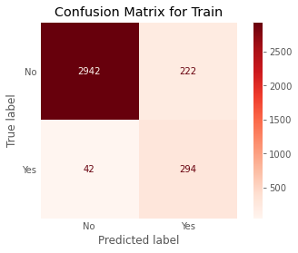

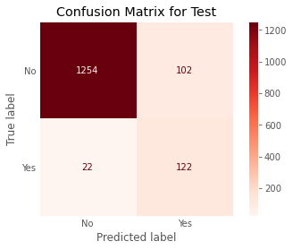

```
 ROC-AUC Score  :Train::  0.902  Test::  0.886
```

```python
scores_statmodel = get_metrics_score(lg3,X_train3,X_test3,y_train,y_test,statmodel,threshold=optimal_threshold_auc_roc,roc=True)
add_score_model(scores_statmodel)
```

ROC-AUC score is 0.89 on test se which is good.

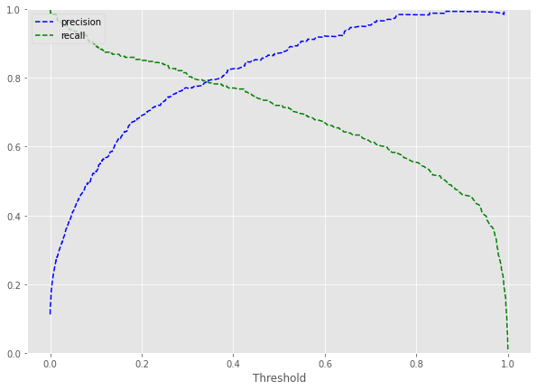

```python
y_scores=lg3.predict(X_train3)
prec, rec, tre = precision_recall_curve(y_train, y_scores,)

def plot_prec_recall_vs_tresh(precisions, recalls, thresholds):
    plt.plot(thresholds, precisions[:-1], 'b--', label='precision')
    plt.plot(thresholds, recalls[:-1], 'g--', label = 'recall')
    plt.xlabel('Threshold')
    plt.legend(loc='upper left')
    plt.ylim([0,1])
plt.figure(figsize=(10,7))
plot_prec_recall_vs_tresh(prec, rec, tre)
plt.show()
```

```python
optimal_threshold_curve = 0.3

scores_opt_curve = get_metrics_score(lg3,X_train3,X_test3,y_train,y_test,statmodel,threshold=optimal_threshold_curve,roc=True)
add_score_model(scores_opt_curve)
```

[output not shown]

```
 ROC-AUC Score  :Train::  0.855  Test::  0.818
```

With this model the False negative cases have gone up and recall for test is 0.646 with 95.8 % accuracy. Model is performing well on training and test set. Model has given a balanced performance, if the bank wishes to maintain a balance between recall and precision this model can be used. Area under the curve has decreased as compared to the initial model but the performance is generalized on training and test set.

### Building Decision Tree

to classify the significant independent varibles to the Personal Loan dependent variables.

```python
df.info()
```

```
<class 'pandas.core.frame.DataFrame'>
RangeIndex: 5000 entries, 0 to 4999
Data columns (total 13 columns):
 #   Column              Non-Null Count  Dtype
---  ------              --------------  -----
 0   Age                 5000 non-null   int64
 1   Experience          5000 non-null   int64
 2   Income              5000 non-null   int64
 3   Family              5000 non-null   category
 4   CCAvg               5000 non-null   float64
 5   Education           5000 non-null   category
 6   Mortgage            5000 non-null   int64
 7   Personal_Loan       5000 non-null   int32
 8   Securities_Account  5000 non-null   category
 9   CD_Account          5000 non-null   category
 10  Online              5000 non-null   category
 11  CreditCard          5000 non-null   category
 12  Regions             5000 non-null   category
dtypes: category(7), float64(1), int32(1), int64(4)
memory usage: 250.0 KB
```

```python
X_dt = df.drop('Personal_Loan', axis=1)
y_dt = df['Personal_Loan']
```

```python
oneHotCols=X_dt.select_dtypes(exclude='number').columns.to_list()
X_dt=pd.get_dummies(X_dt,columns=oneHotCols,drop_first=True)
# Spliting data set
X_train_dt, X_test_dt, y_train_dt, y_test_dt = train_test_split(X_dt, y_dt, test_size=0.3, random_state=1, stratify=y_dt)
```

Observations on dataset:

- Building a decision tree with imbalanced data as the percentage of people who took loan represent almot 9.5% against 90.5% will end up the decision tree to become more biased toward the dominant classes.
- To handle this imbalanced data set,we can pass a dictionary {0:0.15,1:0.85} to the model to specify the weight of each class and the decision tree will give more weightage to class 1.
- class_weight is a hyperparameter for the decision tree classifier.
- Since not being able to identify a potential customer is the biggest loss as mentioned earlier with logistic regression. Hence, recall is the right metric to check the performance of the model.

```python
##  Function to calculate recall score
def get_recall_score(model):
    '''
    model : classifier to predict values of X

    '''
    ytrain_predict = model.predict(X_train_dt)
    ytest_predict = model.predict(X_test_dt)
    # accuracy on training set
    print("\x1b[0;30;47m \033[1mAccuracy : Train :\033[0m",
          model.score(X_train_dt,y_train_dt),
          "\x1b[0;30;47m \033[1mTest:\033[0m",
          model.score(X_test_dt,y_test_dt))
# accuracy on training set
    print("\x1b[0;30;47m \033[1mRecall   : Train :\033[0m",
          metrics.recall_score(y_train_dt,ytrain_predict),
          "\x1b[0;30;47m \033[1mTest:\033[0m",
          metrics.recall_score(y_test_dt,ytest_predict))
    make_confusion_matrix(y_train_dt,ytrain_predict,"Confusion Matric on Train Data")
    make_confusion_matrix(y_test_dt,ytest_predict,"Confusion Matric on Test Data")
```

```
 Accuracy : Train : 1.0  Test: 0.9773333333333334
 Recall   : Train : 1.0  Test: 0.8611111111111112
```

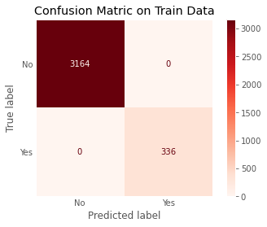

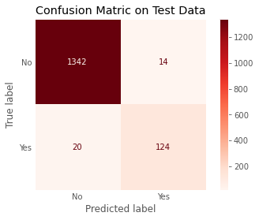

```python
#since data is imbalanced adding weights
model = DecisionTreeClassifier(criterion = 'gini',class_weight={0:0.15,1:0.85}, random_state=1)
model.fit(X_train_dt, y_train_dt)
get_recall_score(model)
```

```python
column_names = list(X_dt.columns)
feature_names = column_names
print(feature_names)
```

```
['Age', 'Experience', 'Income', 'CCAvg', 'Mortgage', 'Family_2', 'Family_3', 'Family_4', 'Education_2', 'Education_3', 'Securities_Account_1', 'CD_Account_1', 'Online_1', 'CreditCard_1', 'Regions_Central', 'Regions_Los Angeles Region', 'Regions_Southern', 'Regions_Superior']
```

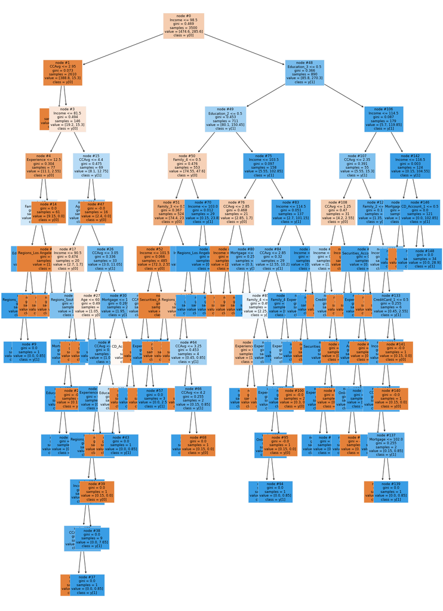

```python
plt.figure(figsize=(20,30))
from sklearn import tree
from sklearn.model_selection import GridSearchCV
out = tree.plot_tree(model,feature_names=feature_names,filled=True,fontsize=9,node_ids=True,class_names=True)
for o in out:
     arrow = o.arrow_patch
     if arrow is not None:
        arrow.set_edgecolor('black')
        arrow.set_linewidth(1)
plt.show()
```

```python
# Text report showing the rules of a decision tree -

print(tree.export_text(model,feature_names=feature_names,show_weights=True))
```

```
|--- Income <= 98.50
|   |--- CCAvg <= 2.95
|   |   |--- weights: [369.60, 0.00] class: 0
|   |--- CCAvg >  2.95
|   |   |--- Income <= 81.50
|   |   |   |--- Experience <= 12.50
|   |   |   |   |--- Family_4 <= 0.50
|   |   |   |   |   |--- Education_3 <= 0.50
|   |   |   |   |   |   |--- Regions_Southern <= 0.50
|   |   |   |   |   |   |   |--- weights: [0.00, 1.70] class: 1
|   |   |   |   |   |   |--- Regions_Southern >  0.50
|   |   |   |   |   |   |   |--- weights: [0.00, 0.85] class: 1
|   |   |   |   |   |--- Education_3 >  0.50
|   |   |   |   |   |   |--- weights: [0.30, 0.00] class: 0
|   |   |   |   |--- Family_4 >  0.50
|   |   |   |   |   |--- Regions_Los Angeles Region <= 0.50
|   |   |   |   |   |   |--- weights: [1.50, 0.00] class: 0
|   |   |   |   |   |--- Regions_Los Angeles Region >  0.50
|   |   |   |   |   |   |--- weights: [0.15, 0.00] class: 0
|   |   |   |--- Experience >  12.50
|   |   |   |   |--- weights: [9.15, 0.00] class: 0
|   |   |--- Income >  81.50
|   |   |   |--- CCAvg <= 4.40
|   |   |   |   |--- Age <= 46.00
|   |   |   |   |   |--- Income <= 90.50
|   |   |   |   |   |   |--- weights: [2.10, 0.00] class: 0
|   |   |   |   |   |--- Income >  90.50
|   |   |   |   |   |   |--- Regions_Southern <= 0.50
|   |   |   |   |   |   |   |--- Mortgage <= 89.00
|   |   |   |   |   |   |   |   |--- Education_3 <= 0.50
|   |   |   |   |   |   |   |   |   |--- weights: [0.00, 0.85] class: 1
|   |   |   |   |   |   |   |   |--- Education_3 >  0.50
|   |   |   |   |   |   |   |   |   |--- weights: [0.00, 0.85] class: 1
|   |   |   |   |   |   |   |--- Mortgage >  89.00
|   |   |   |   |   |   |   |   |--- weights: [0.15, 0.00] class: 0
|   |   |   |   |   |   |--- Regions_Southern >  0.50
|   |   |   |   |   |   |   |--- weights: [0.45, 0.00] class: 0
|   |   |   |   |--- Age >  46.00
|   |   |   |   |   |--- CCAvg <= 3.05
|   |   |   |   |   |   |--- Age <= 60.00
```

[output cut: 165 more lines]

```
|   |   |   |   |   |   |   |--- Income >  112.00
|   |   |   |   |   |   |   |   |--- weights: [0.15, 0.00] class: 0
|   |   |   |   |   |   |--- CreditCard_1 >  0.50
|   |   |   |   |   |   |   |--- weights: [0.15, 0.00] class: 0
|   |   |--- Income >  114.50
|   |   |   |--- Income <= 116.50
|   |   |   |   |--- Mortgage <= 94.50
|   |   |   |   |   |--- weights: [0.00, 1.70] class: 1
|   |   |   |   |--- Mortgage >  94.50
|   |   |   |   |   |--- weights: [0.15, 0.00] class: 0
|   |   |   |--- Income >  116.50
|   |   |   |   |--- CD_Account_1 <= 0.50
|   |   |   |   |   |--- weights: [0.00, 73.95] class: 1
|   |   |   |   |--- CD_Account_1 >  0.50
|   |   |   |   |   |--- weights: [0.00, 28.90] class: 1
```